# Expression levels of quanTIseq tumor genes

Stephanie J. Spielman

2025-01-09

## Setup

```r
renv::load()

library(ggplot2)
theme_set(theme_bw())

set.seed(2025)
```

### Paths

Input files:

```r
tpm_dir <- here::here("analysis", "bulk-deconvolution", "data", "tpm")
tpm_files <- list.files(
  path = tpm_dir,
  full.names = TRUE,
  pattern = ".rds$"
)
```

## Background

`quanTIseq` uses a signature gene list to perform deconvolution: https://github.com/icbi-lab/quanTIseq/blob/039eb16455373915ace33b3ecede09bde697d005/quantiseq/deconvolution/TIL10_signature.txt.

```r
sig_genes_df <- readr::read_tsv(
  "https://raw.githubusercontent.com/icbi-lab/quanTIseq/039eb16455373915ace33b3ecede09bde697d005/quantiseq/deconvolution/TIL10_signature.txt",
  show_col_types = FALSE
)
signature_genes <- sig_genes_df$ID
head(signature_genes)
```

```
[1] "ABCB4"    "ADAM28"   "ADAM6"    "AFF3"     "AKAP2"    "ARHGAP24"
```

```
ABCB4
ADAM28
ADAM6
AFF3
AKAP2
ARHGAP24
```

Within these signature genes, there are 17 genes which they recommend filtering out of tumor analyses based on TCGA expression. From the [`quanTIseq` paper](https://doi.org/10.1186/s13073-019-0638-6):

> Aberrant de-methylation and sequence duplication can lead to over-expression of immune signature genes. Tumor RNA-seq data can be analyzed with quanTIseq setting the `--tumor` option to `TRUE`. This setting discards the signature genes whose `log2(xgl + 1)` expression in the TCGA RNA-seq data exceeds 11 TPM, which are NUPR1, CD36, CSTA, HPGD, CFB, ECM1, FCGBP, PLTP, FXYD6, HOPX, SERPING1, ENPP2, GATM, PDPN, ADAM6, FCRLA, and SLC1A3.

These are also given here: https://github.com/icbi-lab/quanTIseq/blob/039eb16455373915ace33b3ecede09bde697d005/quantiseq/deconvolution/TIL10_TCGA_aberrant_immune_genes.txt

```r
tumor_genes_df <- readr::read_csv(
  "https://raw.githubusercontent.com/icbi-lab/quanTIseq/039eb16455373915ace33b3ecede09bde697d005/quantiseq/deconvolution/TIL10_TCGA_aberrant_immune_genes.txt",
  col_names = "gene_symbol",
  show_col_types = FALSE
)
tumor_genes <- tumor_genes_df$gene_symbol

# Indeed, they are all in the signature:
all(tumor_genes %in% signature_genes)
```

```
[1] TRUE
```

What do these genes do? Aside from being immune signature genes, they are *very briefly:*

- `NUPR1`: Trans factor involved in cellular stress and tumor progression
- `CD36`: Transmembrance receptor involved in lipid uptake
- `CSTA`: Cysteine protease inhibitor
- `HPGD`: Prostaglandin metabolism
- `CFB`: Complement factor B
- `ECM1`: Extracellular matrix
- `FCGBP`: IgGFc-binding protein, involved in tumor metastasis
- `PLTP`: TP53 target gene
- `FXYD6`: phosphohippolin; Na,K-ATPase regulator
- `HOPX`: hox gene, development
- `SERPING1`: serine protease inhibitor
- `ENPP2`: enzyme involved in lipid signaling
- `GATM`: amidinotransferase involved in creatine biosynthesis
- `PDPN`: cell migration; known oncogene
- `ADAM6`: pseudogene expressed in a lot of immune cells
- `FCRLA`: cell surface glycoprotein, involved in inflammatory response
- `SLC1A3`: glutamate transporter

On the whole, while these genes which may be associated with (adult) tumors, they are not necessarily oncogenes or causatively linked to tumor progression.

Since these genes were identified from an database of *adult* tumor samples, it’s not clear whether they have similar biological relevance to pediatric tumors. The purpose of this notebook is to assess whether these genes indeed have aberrantly high expression values compared to the other signature genes in each of our bulk RNA-seq samples.

## Confirm signature genes are present

Since we use gene symbol identifiers here, we should confirm that all gene symbols in the `quanTIseq` reference are indeed present in our data. For this, we’ll check that the signature genes are all present in our mapping table which converted ensembl ids to gene symbols.

```r
map_table <- readr::read_tsv(
  here::here("analysis", "bulk-deconvolution", "data", "reference", "ensembl_symbol.tsv"),
  show_col_types = FALSE
)
map_symbols <- map_table$gene_symbol

all(signature_genes %in% map_symbols)
```

```
[1] FALSE
```

We are indeed missing some! Which ones?

```r
signature_genes[which(!(signature_genes %in% map_symbols))]
```

```
[1] "AKAP2"   "FAM46C"  "GUCY1A3"
```

```
AKAP2
FAM46C
GUCY1A3
```

It turns out the reason these are “missing” is because they have been deprecated since `quanTIseq` was written, or they are aliases for the official gene symbol:

- `AKAP2` was deprecated and replaced with `PALM2AKAP2` (source: https://www.ncbi.nlm.nih.gov/gene/11217)
- `FAM46C` is an alias for `TENT5C` (source: https://www.ncbi.nlm.nih.gov/gene/54855)
- `GUCY1A3` is an alias for `GUCY1A1` (source: https://www.ncbi.nlm.nih.gov/gene/2982)

Are these gene symbols present in our ensembl <-> symbol mapping table?

```r
updated_gene_names <- c("PALM2AKAP2", "TENT5C", "GUCY1A1")
all(updated_gene_names %in% map_symbols)
```

```
[1] TRUE
```

Great, we have these other versions of the gene symbols! We’ll directly replace them in the signature list here.

```r
signature_genes <- dplyr::case_match(
  signature_genes,
  "AKAP2" ~ "PALM2AKAP2",
  "FAM46C" ~ "TENT5C",
  "GUCY1A3" ~ "GUCY1A1",
  .default = signature_genes
)
```

When we actually run `quanTIseq`, we’ll need to make sure that we have matching gene names between our TPM matrices and their signature.

## Prepare the data

We’ll read in the TPM data from all projects into a single long data frame, retaining only the signature genes with an indicator column for which are the tumor genes.

```r
# Create data frame of TPM values for all samples
tpm_df <- tpm_files |>
  purrr::map(readr::read_rds) |>
  # combine into a single matrix
  purrr::reduce(cbind) |>
  as.data.frame() |>
  tibble::rownames_to_column(var = "gene_symbol") |>
  # Filter to signature genes only and add indicator column for tumor genes
  dplyr::filter(gene_symbol %in% signature_genes) |>
  dplyr::mutate(tumor_gene = gene_symbol %in% tumor_genes) |>
  # Long data frame
  tidyr::pivot_longer(
    starts_with("SCPCS"),
    names_to = "sample_id",
    values_to = "tpm"
  )

head(tpm_df)
```

[output not shown]

And confirm once more that we have all the genes:

```r
all(signature_genes %in% tpm_df$gene_symbol)
```

```
[1] TRUE
```

## Expression distributions

First, we’ll visualize distributions of TPM for tumor and non-tumor genes.

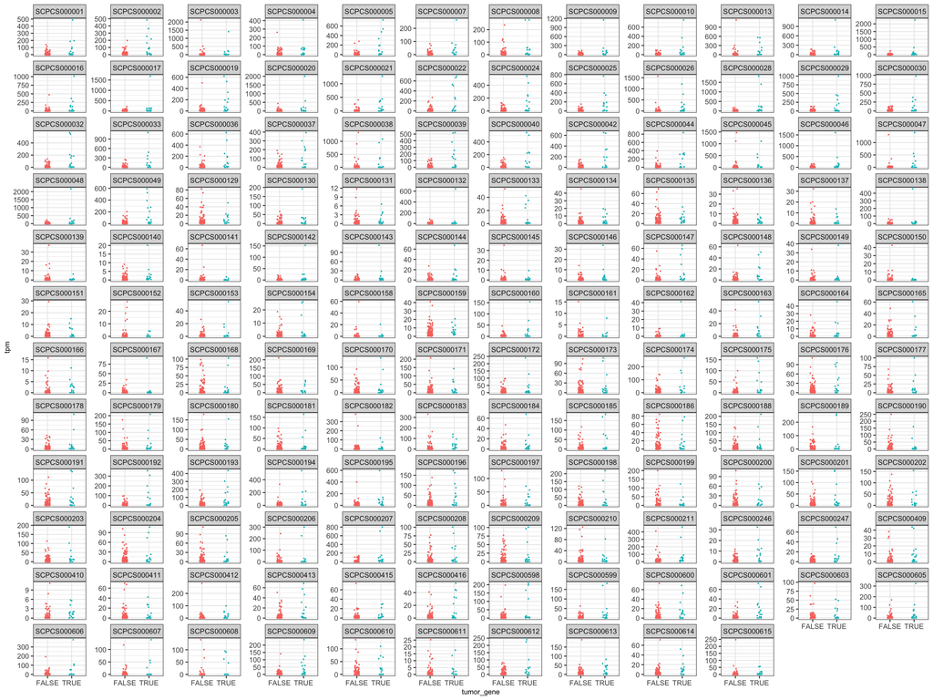

```r
ggplot(tpm_df) +
  aes(x = tumor_gene, y = tpm, color = tumor_gene) +
  geom_jitter(width = 0.1, size = 0.25) +
  facet_wrap(~sample_id, scales = "free_y") +
  theme(
    axis.text = element_text(size = rel(0.8)),
    axis.title = element_text(size = rel(0.8)),
    legend.position = "none"
  )
```

Looking over a great many jitter plots, there does not seem to be a universal trend of aberrantly high expression among tumor genes but of course these plots are rather small!

## Model

We’ll build a mixed-effects model to test if TPM differs between tumor and non-tumor genes. We’ll specify random effects of sample and gene to control for their inherent groupings.

It’s worth noting that, given the distribution of gene expression values, this may not be the most appropriate model framework, but it should suffice to give us a sense of whether or not we want to proceed with the `tumor = TRUE` argument in `quanTIseq`.

```r
lme4::lmer(tpm ~ tumor_gene + (1|sample_id) + (1|gene_symbol), data=tpm_df) |>
  summary()
```

```
Linear mixed model fit by REML ['lmerMod']
Formula: tpm ~ tumor_gene + (1 | sample_id) + (1 | gene_symbol)
   Data: tpm_df

REML criterion at convergence: 263568.3

Scaled residuals:
   Min     1Q Median     3Q    Max
-3.715 -0.179  0.000  0.100 36.595

Random effects:
 Groups      Name        Variance Std.Dev.
 gene_symbol (Intercept)  488.1   22.09
 sample_id   (Intercept)  103.7   10.18
 Residual                3126.5   55.92
Number of obs: 24140, groups:  gene_symbol, 170; sample_id, 142

Fixed effects:
               Estimate Std. Error t value
(Intercept)       8.044      2.016   3.990
tumor_geneTRUE   45.163      5.774   7.821

Correlation of Fixed Effects:
            (Intr)
tumr_gnTRUE -0.286
```

The fixed effect of `tumor_gene` has a t-statistic of 7.821, which is significant. This suggests that there is indeed elevated expression of these tumor genes compared to the other signature genes.

## Conclusion

Although the visual inspection did not necessarily show a universal trend, the mixed effects model suggests that there is indeed, on average, higher expression of these tumor-associated immune signature genes. We should therefore consider using `tumor=TRUE` mode and excluding them in analysis.